# Statistical Inference in Biology Assignment 3

201900700284 Yang Sihao

2021/4/4

# Part 1

# The Null Hypothesis

## 1、Stickleback fish occurs with equal probability through all areas of a pond

## 2、Patients don’t change in mean body mass during a hospital stay

## 3、The amount of rainfall per day in a rainforest haven a normal distribution

## 4、On average males and females weighs the same in bald eagles

## 5、Cats have the same strength in their dominant front paw (usually the right) than in their other front paw (usually the left)

# Part 2

# 1、The Null and the alternative hypotheses.

## Null hypotheses: The nonpathogenic gut microbes don’t trigger onset of EAE

## Alternative hypotheses: The nonpathogenic gut microbes trigger onset of EAE

# 2、Present the data.

## Load the data.

```r
eae.df <- read.csv("eae.csv", stringsAsFactors = T)
eae.df
```

```
##    group autoreactive
## 1     GF        11.64
## 2     GF         4.51
## 3     GF         1.12
## 4     GF         2.62
## 5     GF         0.37
## 6     GF         0.61
## 7     GF         0.71
## 8     GF         0.82
## 9    SPF        18.87
## 10   SPF        15.65
## 11   SPF        13.45
## 12   SPF        12.95
## 13   SPF         6.01
## 14   SPF         1.84
## 15   SPF         0.56
## 16   SPF         2.46
```

## Create the boxplot.

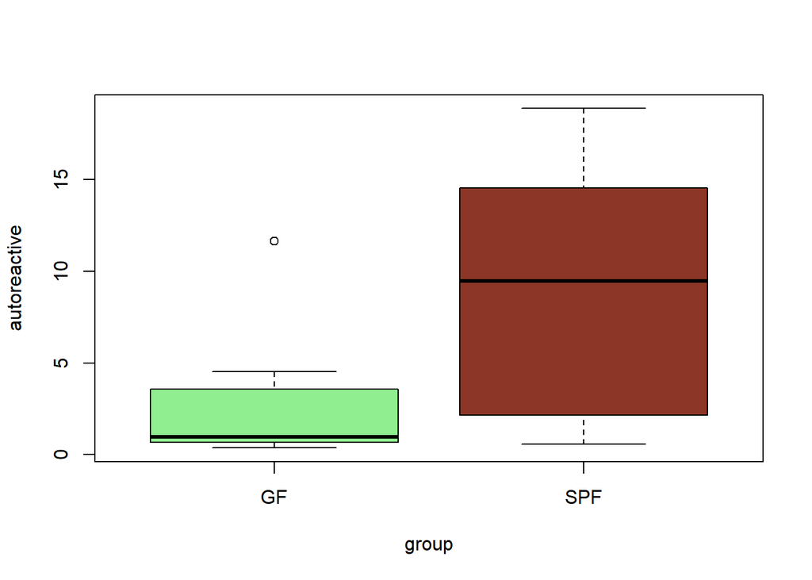

```r
boxplot(autoreactive~group,data = eae.df,col=c("lightgreen", "tomato4"))
```

## Create two vector of “GF” and “SPF”.

```r
GF<-eae.df$autoreactive[eae.df$group=="GF"]
SPF<-eae.df$autoreactive[eae.df$group=="SPF"]
```

## Create the histogram.

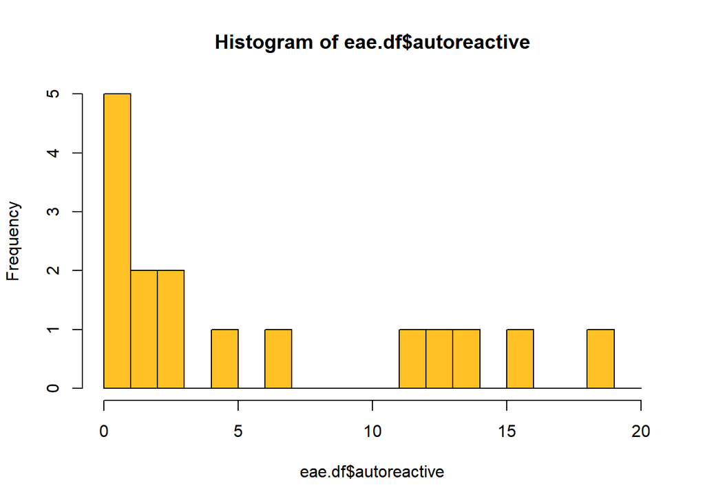

```r
hist(eae.df$autoreactive,col = "goldenrod1",breaks = 0:20)
```

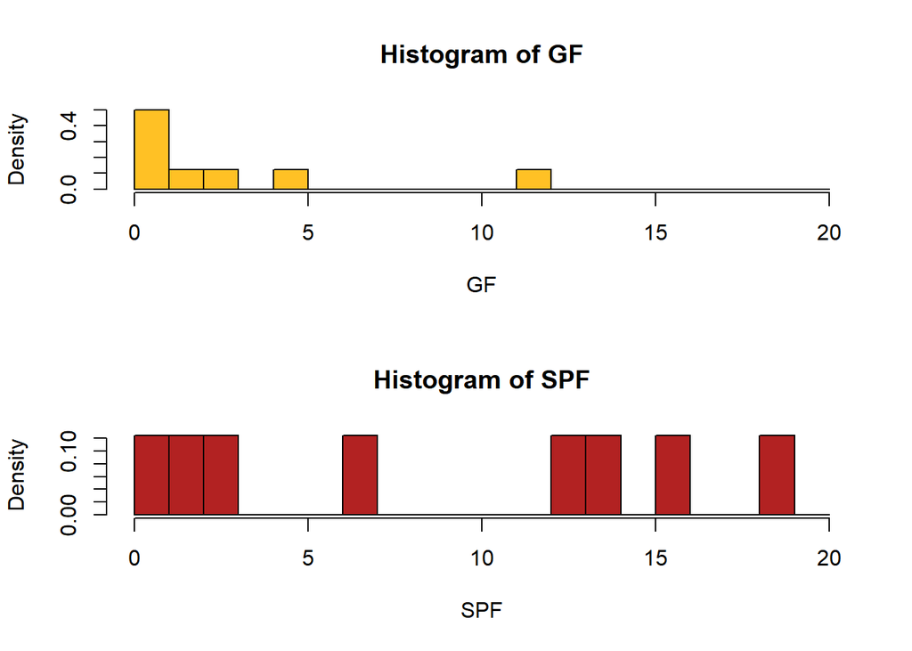

```r
par(mfrow = c(2, 1))
hist(GF, col = "goldenrod1", breaks = 0:20, freq = F)
hist(SPF, col = "firebrick", breaks = 0:20, freq = F)
```

# 3、Visually and formally assess normality of the data.

## Calculate the min、max, and Create the normality of “GF” and “SPF”

```r
autoreactive.min<-min(eae.df$autoreactive)
autoreactive.max<-max(eae.df$autoreactive)
autoreactive.range<-seq(from=autoreactive.min,to=autoreactive.max,by=0.1)

GF.norm<-dnorm(autoreactive.range,mean = mean(GF),sd=sd(GF))
SPF.norm<-dnorm(autoreactive.range,mean = mean(SPF),sd=sd(SPF))
```

## Create the histogram with Norm lines.

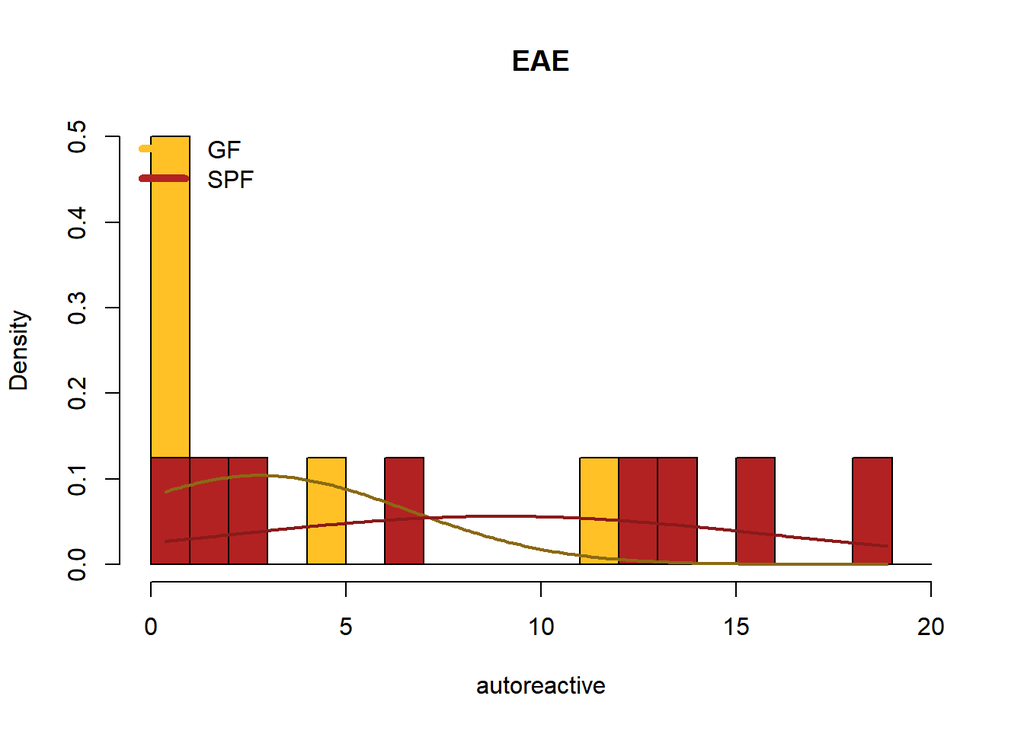

```r
hist(GF, col = "goldenrod1", breaks = 0:20, freq = F, main = "EAE", xlab = "autoreactive")
hist(SPF, col = "firebrick", breaks = 0:20, freq = F, add = T)
lines(autoreactive.range, GF.norm, col = "goldenrod4", lwd = 2,)
lines(autoreactive.range, SPF.norm, col = "firebrick4", lwd = 2,)
legend("topleft", legend = c("GF", "SPF"), col = c("goldenrod1", "firebrick"), lty = 1, lwd = 5, bty = "n")
```

## The data seems to not fit normal distribution.

## Create the QQ plot for GF.

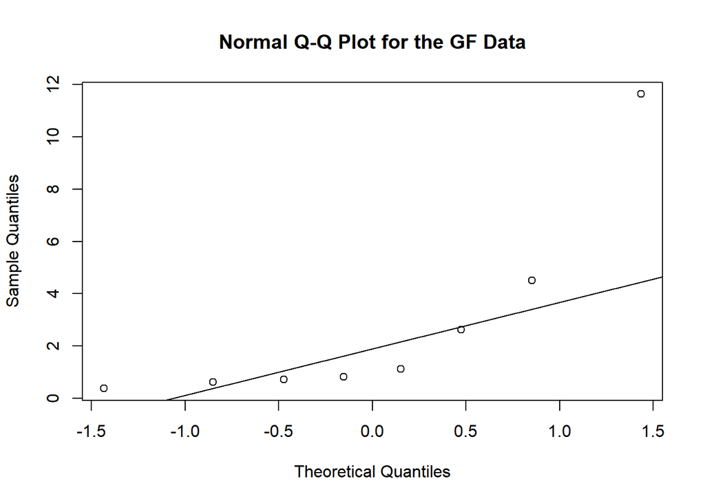

```r
qqnorm(GF, main = "Normal Q-Q Plot for the GF Data")
qqline(GF)
```

## Create the QQ plot for SPF.

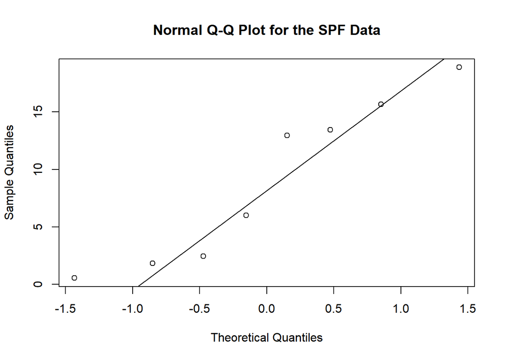

```r
qqnorm(SPF, main = "Normal Q-Q Plot for the SPF Data")
qqline(SPF)
```

## Visually, our data doesn’t fit normal distribution in both groups.

## Use the shapiro test.

```r
shapiro.test(GF)
```

```
##
##  Shapiro-Wilk normality test
##
## data:  GF
## W = 0.68628, p-value = 0.001574
```

```r
shapiro.test(SPF)
```

```
##
##  Shapiro-Wilk normality test
##
## data:  SPF
## W = 0.89832, p-value = 0.279
```

# 4、Perform statistical tests：

## Use the t-test.

```r
eae.t <- t.test(autoreactive ~ group, data = eae.df, alternative = "two.sided", var.equal = T)
eae.t
```

```
##
##  Two Sample t-test
##
## data:  autoreactive by group
## t = -2.1679, df = 14, p-value = 0.04789
## alternative hypothesis: true difference in means is not equal to 0
## 95 percent confidence interval:
##  -12.28171224  -0.06578776
## sample estimates:
##  mean in group GF mean in group SPF
##           2.80000           8.97375
```

## The p-value from the t-test is 0.04789.

## Use the welch t-test.

```r
t.test(autoreactive ~ group, data = eae.df)
```

```
##
##  Welch Two Sample t-test
##
## data:  autoreactive by group
## t = -2.1679, df = 10.778, p-value = 0.05346
## alternative hypothesis: true difference in means is not equal to 0
## 95 percent confidence interval:
##  -12.4575705   0.1100705
## sample estimates:
##  mean in group GF mean in group SPF
##           2.80000           8.97375
```

## The p-value from the t-test is 0.05346.

## Calculate the mean difference between the group:

```r
eae.mean <- mean(SPF) - mean(GF)
eae.mean
```

```
## [1] 6.17375
```

## A vector to store the 10,000 permutations. Lets call it perm and initialize as empty numerical:

```r
perm <- double(0)
```

```r
p <- sample(eae.df$autoreactive)
p.GF <- p[1:length(GF)]
p.SPF <- p[length(GF):length(p)]
p.GF
```

```
## [1]  2.62 18.87  0.71 13.45  0.61  1.12  2.46 12.95
```

```r
p.SPF
```

```
## [1] 12.95  0.82  4.51 11.64  0.56  1.84 15.65  6.01  0.37
```

## The mean difference

```r
p.mu <- mean(p.SPF) - mean(p.GF)
p.mu
```

```
## [1] -0.5598611
```

## Run this permutation 10,000 times and collect the 10,000 outcomes:

```r
N <- 10e3
perm <- double(0)
for(i in 1:N){
  p <- sample(eae.df$autoreactive,length(eae.df$autoreactive),replace = F)
 p.GF <- p[1:length(GF)]
 p.SPF <- p[(length(GF)+1):length(p)]
 p.mu <- mean(p.GF) - mean(p.SPF)
 perm <- c(perm, p.mu)
}
```

## Calculate the absolute value of the observed mean:

```r
eae.mean.abs <- abs(eae.mean)
eae.mean.abs
```

```
## [1] 6.17375
```

## The more extreme means

```r
perm.sig <- perm[perm < -eae.mean.abs | perm > eae.mean.abs]
perm.sig.n <- length(perm.sig)
perm.sig.n
```

```
## [1] 401
```

## We will also find the not extreme means:

```r
perm.nsig <- perm[!(perm < -eae.mean.abs | perm > eae.mean.abs)]
perm.nsig.n <- length(perm.nsig)
perm.nsig.n
```

```
## [1] 9599
```

## A quick assertion check:

```r
perm.nsig.n + perm.sig.n == N
```

```
## [1] TRUE
```

## Now we can calculate the p-value as a proportion.

```r
p.pval <- perm.sig.n / length(perm)
p.pval
```

```
## [1] 0.0401
```

## The significant simulations.

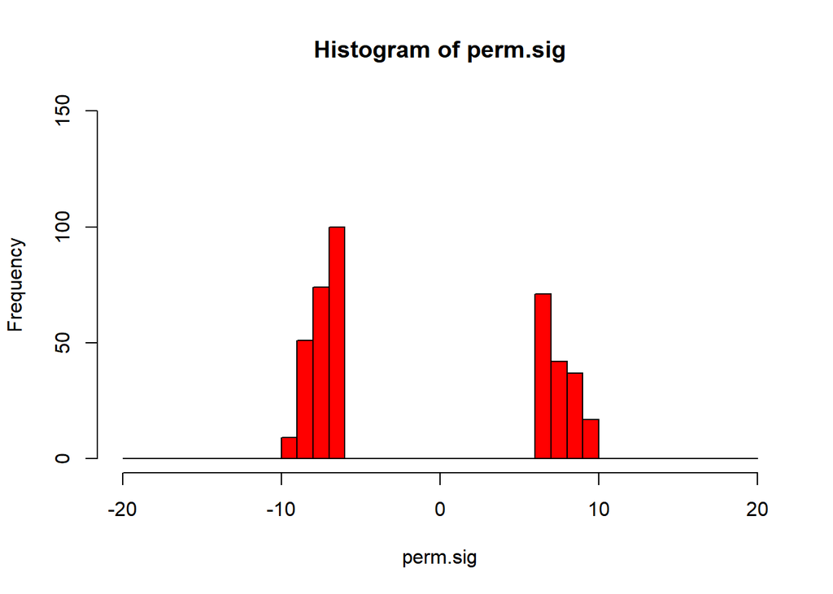

```r
hist(perm.sig, breaks = -20:20, col = "red", ylim =c(0,150 ))
```

## The not significant simulations.

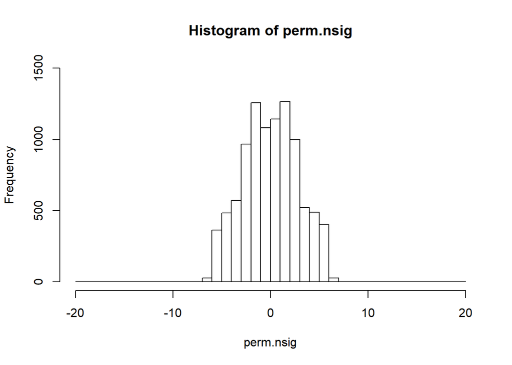

```r
hist(perm.nsig, breaks = -20:20, col = "white",ylim = c(0,1500))
```

## Add the annotations.

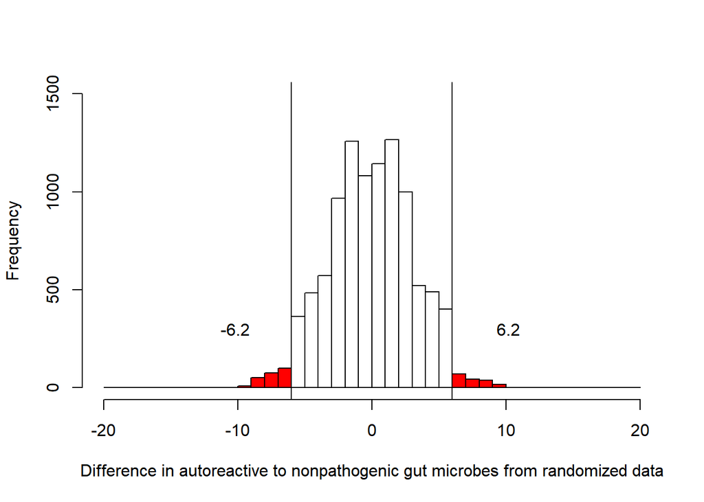

```r
hist(perm.nsig, breaks = -20:20, col = "white", main = "", xlab = "Difference in autoreactive to nonpathogenic gut microbes from randomized data", ylim = c(0,1500))
hist(perm.sig, breaks = -20:20, col = "red", add = T)

#Two vertical lines at +/- eae.mean
abline(v = -round(eae.mean.abs, 0))
abline(v = round(eae.mean.abs, 0))

#Two labels with the +/- eae.mean
text(-round(eae.mean.abs, 1) - 4, 300, sprintf('%.1f', -eae.mean.abs))
text(round(eae.mean.abs, 1) + 4, 300, sprintf('%.1f', eae.mean.abs))
```

# 5、Description of my results.

## 1. Yes.The boxplot is well suited to present the difference of data between GF and SPF.

## 2. Maybe not. Though the histogram could show the data directly, it is hard to find some difference between GF and SPF.

## 3.“SPF” is，“GF” is not. The QQ plot and Shapiro test, the data of SPF is fitted the normal line and p-value >alpha=0.05, the data of GF doesn’t fit and its p-value <alpha=0.05.

## 4.Welch t-test can be selected when the variances of the two groups are not equal. t-test is for normal distribution data with unknown population standard deviation σ.

## 5.Actually no. The p-value of data is less than alpha =0.05 and the variances of the two groups are not equal because the Welch t-test worked.

## 6.Yes, the p-value of data is more than alpha =0.05 and the variances of the two groups are not equal.

# 6、Conclusion

## Given the p-value is less than alpha=0.05, then we reject the Null hypotheses and accept the alternative hypotheses.

## Therefore, the answer for research question is The nonpathogenic gut microbes trigger onset of EAE. The EAE could be initiated by nonpathogenic microbes living in the gut.

## The sample size is not large enough, and the results obtained are not enough to support the relevant content. Moreover, in this study, relevant influencing factors can still be tested by adding corresponding experimental groups.